# Análise dos resultados

Gere uma análise descritiva e exploratória dos dados obtidos para ter um entendimento inicial dos dados.

## Sobre os dados

### Leitura e pré-processamento dos dados

A seguir realizamos a leitura dos dados, e para fins de simplificação das análises convertemos as colunas respectivas à ordenação de origens e soluções de conflitos para colunas númericas, em que o nome da coluna se refere à origem ou solução, enquanto o valor se refere a posição atribuída para ela pelo respondente. Além disso, filtraremos respostas em branco ou com formato incorreto.

```r
respostas_raw <- read_csv("../data/respostas_raw.csv", col_names = c(
  'data_hora', 'periodo', 'disciplinas_cursadas', 'projeto_presencial',
  'projeto_remoto', 'n_max_membros', 'conflito_prioridades', 'conflito_gerenciamento',
  'conflito_tecnico', 'conflito_prazos', 'conflito_personalidades', 'conflito_1', 'conflito_2',
  'conflito_3', 'conflito_4', 'conflito_5', 'solucao_confronto', 'solucao_negociacao',
  'solucao_evasao', 'solucao_apazig', 'solucao_imposicao', 'solucao_1', 'solucao_2', 'solucao_3',
  'solucao_4', 'solucao_5'
), col_types = 'cccffiiiiiiccccciiiiiccccc', skip = 1)
```

```r
respostas_clean <-
  respostas_raw %>%
  filter(if_all(.fns = function(x) !is.na(x))) %>%
  mutate(
    periodo = ifelse(periodo == "Anterior ou igual a 2015.2", "≤ 2015.2", periodo),
    periodo = factor(
      periodo,
      levels = c(
        "≤ 2015.2",
        "2016.1",
        "2016.2",
        "2017.1",
        "2017.2",
        "2018.1",
        "2018.2",
        "2019.1",
        "2019.2",
        "2020.1",
        "2020.2"
      ),
      ordered = T
    ),
    impacto_prioridades = case_when(
      conflito_1 == "Prioridades" ~ 5,
      conflito_2 == "Prioridades" ~ 4,
      conflito_3 == "Prioridades" ~ 3,
      conflito_4 == "Prioridades" ~ 2,
      conflito_5 == "Prioridades" ~ 1
    ),
    impacto_gerenciamento = case_when(
      conflito_1 == "Gerenciamento" ~ 5,
      conflito_2 == "Gerenciamento" ~ 4,
      conflito_3 == "Gerenciamento" ~ 3,
      conflito_4 == "Gerenciamento" ~ 2,
      conflito_5 == "Gerenciamento" ~ 1
    ),
    impacto_tecnico = case_when(
      conflito_1 == "Questões técnicas" ~ 5,
      conflito_2 == "Questões técnicas" ~ 4,
      conflito_3 == "Questões técnicas" ~ 3,
      conflito_4 == "Questões técnicas" ~ 2,
      conflito_5 == "Questões técnicas" ~ 1
    ),
    impacto_prazos = case_when(
      conflito_1 == "Prazos" ~ 5,
      conflito_2 == "Prazos" ~ 4,
      conflito_3 == "Prazos" ~ 3,
      conflito_4 == "Prazos" ~ 2,
      conflito_5 == "Prazos" ~ 1
    ),
    impacto_personalidade = case_when(
      conflito_1 == "Personalidade" ~ 5,
      conflito_2 == "Personalidade" ~ 4,
      conflito_3 == "Personalidade" ~ 3,
      conflito_4 == "Personalidade" ~ 2,
      conflito_5 == "Personalidade" ~ 1
    ),
    efetividade_confronto = case_when(
      solucao_1 == "Confronto" ~ 5,
      solucao_2 == "Confronto" ~ 4,
      solucao_3 == "Confronto" ~ 3,
      solucao_4 == "Confronto" ~ 2,
      solucao_5 == "Confronto" ~ 1
    ),
    efetividade_negociacao = case_when(
      solucao_1 == "Negociação" ~ 5,
      solucao_2 == "Negociação" ~ 4,
      solucao_3 == "Negociação" ~ 3,
      solucao_4 == "Negociação" ~ 2,
      solucao_5 == "Negociação" ~ 1
    ),
    efetividade_evasao = case_when(
      solucao_1 == "Evasão" ~ 5,
      solucao_2 == "Evasão" ~ 4,
      solucao_3 == "Evasão" ~ 3,
      solucao_4 == "Evasão" ~ 2,
      solucao_5 == "Evasão" ~ 1
    ),
    efetividade_apazig = case_when(
      solucao_1 == "Apaziguamento" ~ 5,
      solucao_2 == "Apaziguamento" ~ 4,
      solucao_3 == "Apaziguamento" ~ 3,
      solucao_4 == "Apaziguamento" ~ 2,
      solucao_5 == "Apaziguamento" ~ 1
    ),
    efetividade_imposicao = case_when(
      solucao_1 == "Imposição" ~ 5,
      solucao_2 == "Imposição" ~ 4,
      solucao_3 == "Imposição" ~ 3,
      solucao_4 == "Imposição" ~ 2,
      solucao_5 == "Imposição" ~ 1
    ),
    apenas_presencial = projeto_presencial == "Sim" & projeto_remoto == "Não",
    apenas_remoto = projeto_presencial == "Não" & projeto_remoto == "Sim",
    ambos = projeto_presencial == "Sim" & projeto_remoto == "Sim",
    nenhum = projeto_presencial == "Não" & projeto_remoto == "Não"
  ) %>%
  select(-matches("_[1-5]"), -data_hora)

rm(respostas_raw)
```

## Caracterização dos respondentes

Nesta seção, caracterizaremos os respondentes do formulário considerando alguns fatores explicados em cada subseção.

### Período de ingresso

Pelo gráfico, pudemos constatar que houve uma predominância de respostas de alunos que estão na segunda metade do curso (cursaram mais de cinco períodos), em especial os ingressantes no 2018.1 que representa mais de 1/4 das respostas.

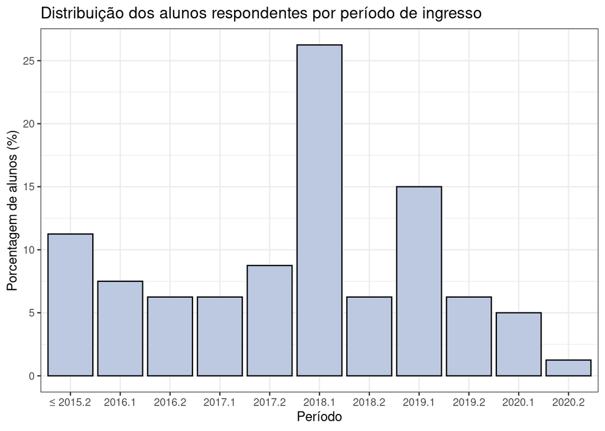

```r
respostas_clean %>%
  count(periodo) %>%
  mutate(n = n/nrow(respostas_clean) * 100) %>%
  ggplot(aes(x = periodo, y = n)) +
  geom_bar(stat = 'identity', position = "dodge", color = 'black', fill = '#bdc9e1') +
  labs(x = "Período",
       y = "Porcentagem de alunos (%)",
       title = "Distribuição dos alunos respondentes por período de ingresso") +
  scale_y_continuous(breaks = seq(0, 100, 5))
```

### Disciplinas cursadas

É possível notar, a partir do gráfico, que quatro disciplinas (LP2, PLP, PSOFT, ES) já foram cursadas por mais de 70% dos alunos, enquanto que duas disciplinas Projeto em Computação I e II (P1 e P2) foram cursadas por cerca de 30% destes.

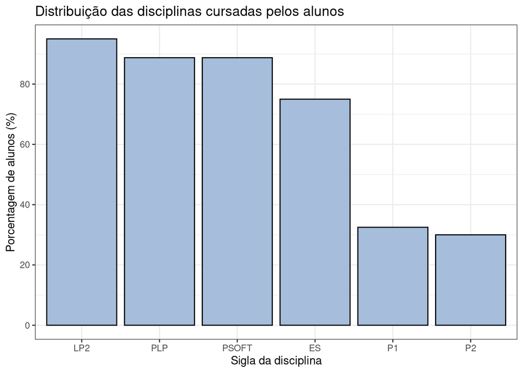

```r
respostas_clean %>%
  separate_rows(disciplinas_cursadas, sep = ", ") %>%
  select(disciplinas_cursadas) %>%
  mutate(disciplinas_cursadas = case_when(
    disciplinas_cursadas == "Laboratório de Programação II (LP2)" ~ "LP2",
    disciplinas_cursadas == "Projeto de Software (PSOFT)" ~ "PSOFT",
    disciplinas_cursadas == "Paradigmas de Linguagens Programação (PLP)" ~ "PLP",
    disciplinas_cursadas == "Engenharia de Software (ES)" ~ "ES",
    disciplinas_cursadas == "Projeto em Computação I (P1)" ~ "P1",
    disciplinas_cursadas == "Projeto em Computação II (P2)" ~ "P2"
  )) %>%
  count(disciplinas_cursadas) %>%
  mutate(n = n/nrow(respostas_clean) * 100) %>%
  ggplot(aes(x = reorder(disciplinas_cursadas, -n), y = n)) +
  geom_bar(stat = "identity", position = "dodge", color = 'black', fill = '#a6bddb') +
  labs(x = "Sigla da disciplina",
       y = "Porcentagem de alunos (%)",
       title = "Distribuição das disciplinas cursadas pelos alunos") +
  scale_y_continuous(breaks = seq(0, 100, 20))
```

```r
# TODO: gráfico de quantidade de disciplinas cursadas por aluno
```

### Tamanho do maior grupo que participou

Quanto ao tamanho do maior grupo em que o estudante participou, notamos que a resposta de maior frequência foi cinco, além temos uma média de 8.95 membros e uma mediana de 10 membros.

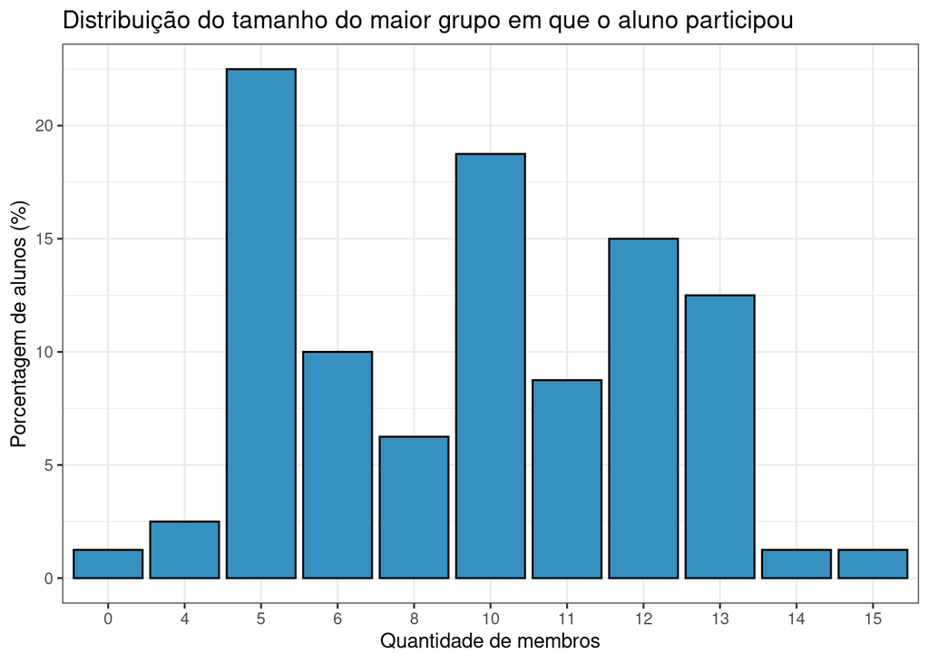

```r
respostas_clean %>%
  count(n_max_membros) %>%
  mutate(n = n/nrow(respostas_clean) * 100) %>%
  ggplot(aes(x = as.factor(n_max_membros), y = n)) +
  geom_bar(stat = "identity", position = "dodge", color = 'black', fill = '#3690c0') +
  labs(x = "Quantidade de membros",
       y = "Porcentagem de alunos (%)",
       title = "Distribuição do tamanho do maior grupo em que o aluno participou")
```

### Participação em projetos

Por fim, agrupamos os respondentes pelo tipo de participação em grupos de projeto: participaram de projetos tanto no regime presencial quanto remoto; apenas no remoto; apenas no presencial; e em nenhum dos regimes.

Vemos uma forte predominância dos alunos que participaram de projeto em ambos os regimes. E vemos que uma pequena parcela não participou em projetos, estes serão excluídos nas futuras análises.

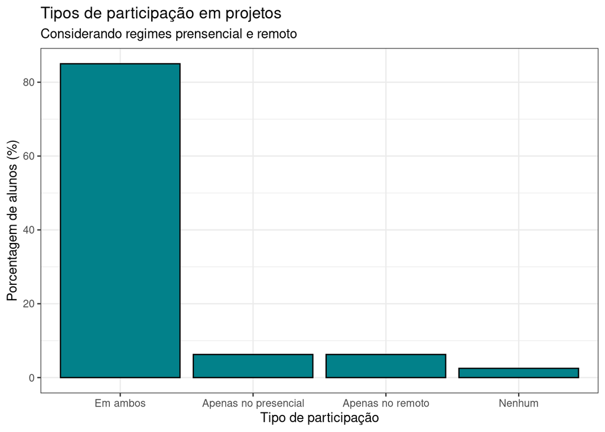

```r
respostas_clean %>%
  select(apenas_presencial, apenas_remoto, ambos, nenhum) %>%
  pivot_longer(cols = everything(), names_to = "Tipo", values_to = "Value") %>%
  filter(Value == T) %>%
  count(Tipo) %>%
  mutate(Tipo = case_when(
    Tipo == "ambos" ~ "Em ambos",
    Tipo == "apenas_presencial" ~ "Apenas no presencial",
    Tipo == "apenas_remoto" ~ "Apenas no remoto",
    Tipo == "nenhum" ~ "Nenhum"
  ),
  n = n/nrow(respostas_clean) * 100) %>%
  ggplot(aes(x = reorder(Tipo, -n), y = n)) +
  geom_bar(stat = "identity", position = "dodge", color = 'black', fill = '#02818a') +
  labs(x = "Tipo de participação",
       y = "Porcentagem de alunos (%)",
       title = "Tipos de participação em projetos",
       subtitle = "Considerando regimes prensencial e remoto")
```

## Questões de pesquisa

Nesta seção, continuaremos com a análise de dados, porém com foco em responder as questões de pesquisa (QP).

```r
respostas_uteis <- respostas_clean %>% filter(nenhum == FALSE)
size_d <- nrow(respostas_uteis)
```

### QP1: Quais os tipos de conflito mais recorrentes nos times de desenvolvimento?

No Gráfico I, descrevemos a distribuição das respostas obtidas no questionário com relação a frequência com que determinado fator levou a conflitos no time. A partir dele, considerando as modas das respostas, podemos ordenar os fatores por sua frequência do menos para o mais frequente: **Personalidades, Prioridades, Questões técnicas, Gerenciamento e Prazos**. Além disso, temos alguns destaques como:

- Os fatores Prazos e Gerenciamento tem um empate na moda no valor 4, entretanto o primeiro destaca-se por ter o maior percentual de resposta no valor 5.
- O fator Personalidades destaca-se pelo maior percentual no valor 1, corroborando assim nossa ordenação.
- Os fatores Personalidades e Prazos foram os únicos nos quais o percentual de respostas cinco superou 15%.

Enquanto no Gráfico II, apresentamos os tipos de conflito ordenados pela média das respostas, com um intervalo de confiança de 95%. Vemos que o fator **Prazos** é, em média, o maior e também o único cujo intervalo de confiança não se sobrepõe aos demais. Enquanto que em todos os outros fatores temos sobreposição nos intervalos.

#### Gráfico I

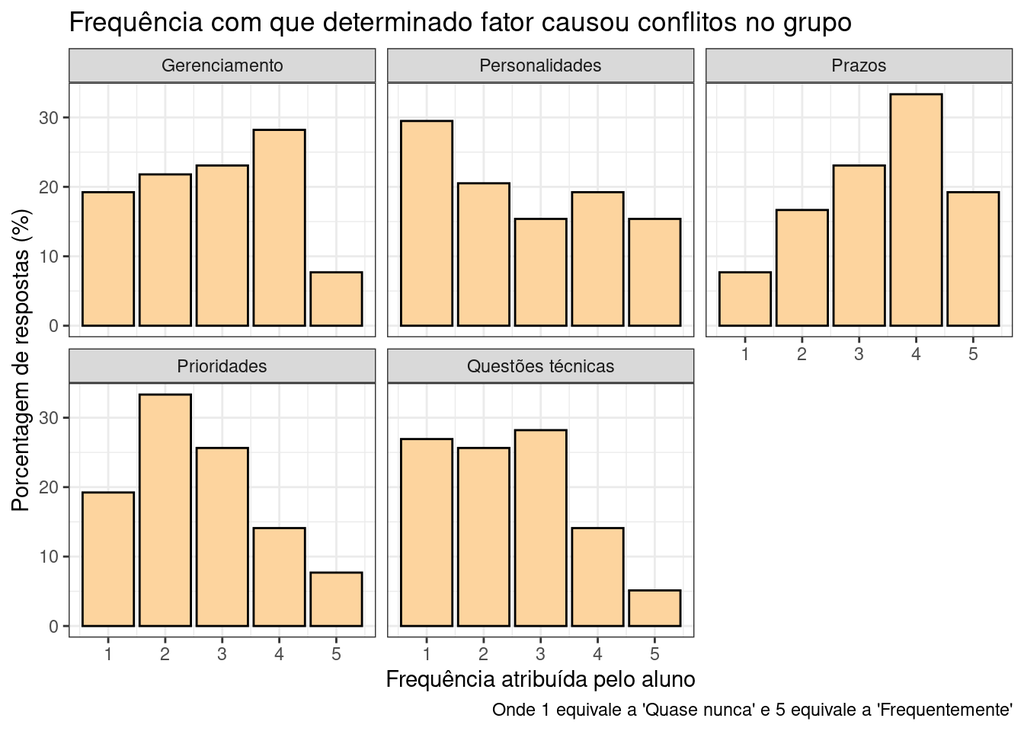

```r
respostas_uteis %>%
  select(starts_with("conflito_")) %>%
  pivot_longer(
    cols = starts_with("conflito_"),
    names_to = "tipo_de_conflito",
    values_to = "freq"
  ) %>%
  mutate(
    tipo_de_conflito = case_when(
      tipo_de_conflito == "conflito_prioridades" ~ "Prioridades",
      tipo_de_conflito == "conflito_gerenciamento" ~ "Gerenciamento",
      tipo_de_conflito == "conflito_tecnico" ~ "Questões técnicas",
      tipo_de_conflito == "conflito_prazos" ~ "Prazos",
      tipo_de_conflito == "conflito_personalidades" ~ "Personalidades",
    )
  ) %>%
  count(tipo_de_conflito, freq) %>%
  mutate(n = n/size_d * 100) %>%
  ggplot(aes(x = freq, y = n)) +
  geom_bar(stat = 'identity', position = 'dodge', color = 'black', fill = '#fdd49e') +
  facet_wrap( ~ tipo_de_conflito) +
  labs(x = "Frequência atribuída pelo aluno",
       y = "Porcentagem de respostas (%)",
       caption = "Onde 1 equivale a 'Quase nunca' e 5 equivale a 'Frequentemente'",
       title = "Frequência com que determinado fator causou conflitos no grupo")
```

#### Gráfico II

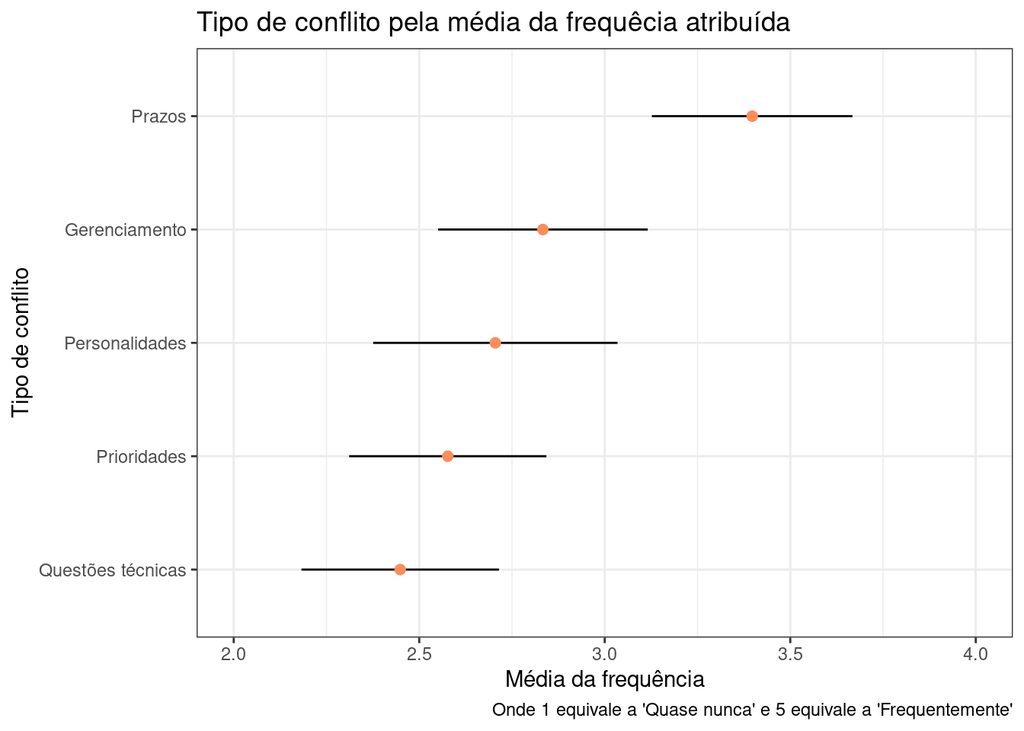

```r
respostas_uteis %>%
  select(starts_with("conflito_")) %>%
  summarise(across(.fns = c("mean" = mean, "var" = var), .names = "{.col}_{.fn}")) %>%
  pivot_longer(
    cols = starts_with("conflito_"),
    names_to = "tipo_de_conflito",
    values_to = "value"
  ) %>% rowwise() %>%
  mutate(
    metric = str_split(tipo_de_conflito, "_")[[1]][3],
    tipo_de_conflito = str_split(tipo_de_conflito, "_")[[1]][2],
    tipo_de_conflito = case_when(
      tipo_de_conflito == "prioridades" ~ "Prioridades",
      tipo_de_conflito == "gerenciamento" ~ "Gerenciamento",
      tipo_de_conflito == "tecnico" ~ "Questões técnicas",
      tipo_de_conflito == "prazos" ~ "Prazos",
      tipo_de_conflito == "personalidades" ~ "Personalidades",
    )
  ) %>% ungroup() %>%
  pivot_wider(id_cols = tipo_de_conflito, values_from = "value", names_from = "metric") %>%
  mutate(ic.low = mean + qt(0.025, df = size_d-1) * sqrt(var/size_d),
         ic.high = mean + qt(0.975, df = size_d-1) * sqrt(var/size_d)) %>%
  ggplot(aes(y = reorder(tipo_de_conflito, mean))) +
  geom_linerange(aes(xmin = ic.low, xmax = ic.high)) +
  geom_point(aes(x = mean), color = '#fc8d59', size = 2) +
  scale_x_continuous(limits = c(2, 4)) +
  labs(title = "Tipo de conflito pela média da frequêcia atribuída",
       y = "Tipo de conflito",
       x = "Média da frequência",
       caption = "Onde 1 equivale a 'Quase nunca' e 5 equivale a 'Frequentemente'")
```

### QP2: Qual fonte de conflitos teve maior impacto negativo no desenvolvimento do projeto?

No Gráfico III, encontramos a distribuição das respostas sobre o impacto de cada fator de conflito no grupo.

**Gerenciamento** mostra-se com altas porcentagens de respostas nos valore 4 e 5, o que sugere um forte impacto no projeto. Isto é confirmado no Gráfico IV, ao vermos que sua média é de fato a maior. Entretanto, seu intervalo de confiança sobrepõe-se ao do fator **Prazos**, que tem uma frequência de resposta quase uniforme entre 2 e 5.

Quanto a **Personalidades**, este figura com altos índices nos valores 1 e 5, o que parece explicar seu extenso intervalo de confiança, que sobrepõe-se quase inteiramente ao de **Questões técnicas** e parcialmente ao de **Prioridades** e **Prazos**.

#### Gráfico III

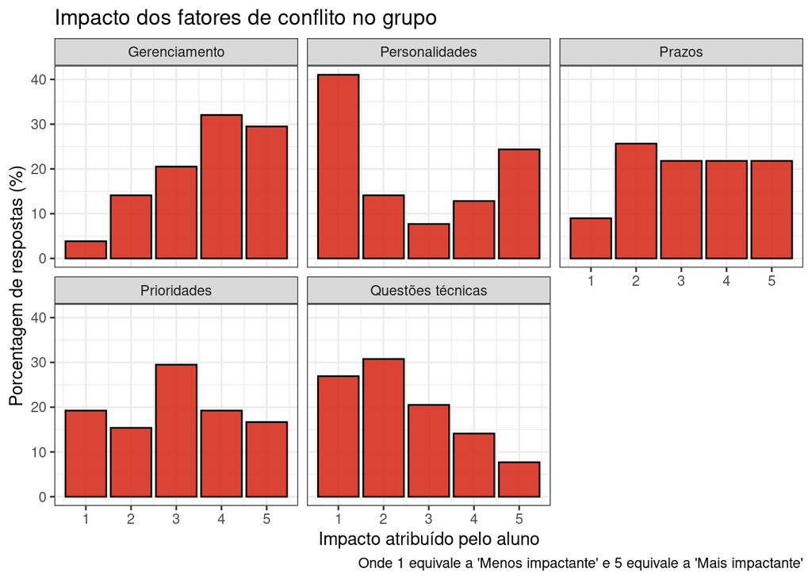

```r
respostas_uteis %>%
  select(starts_with("impacto_")) %>%
  pivot_longer(
    cols = starts_with("impacto_"),
    names_to = "tipo_de_conflito",
    values_to = "impacto"
  ) %>%
  mutate(
    tipo_de_conflito = case_when(
      tipo_de_conflito == "impacto_prioridades" ~ "Prioridades",
      tipo_de_conflito == "impacto_gerenciamento" ~ "Gerenciamento",
      tipo_de_conflito == "impacto_tecnico" ~ "Questões técnicas",
      tipo_de_conflito == "impacto_prazos" ~ "Prazos",
      tipo_de_conflito == "impacto_personalidade" ~ "Personalidades",
    )
  ) %>%
  count(tipo_de_conflito, impacto) %>%
  mutate(n = n/size_d * 100) %>%
  ggplot(aes(x = impacto, y = n)) +
  geom_bar(stat = 'identity', position = 'dodge', color = 'black', fill = '#d7301f', alpha = .9) +
  facet_wrap( ~ tipo_de_conflito) +
  labs(x = "Impacto atribuído pelo aluno",
       y = "Porcentagem de respostas (%)",
       caption = "Onde 1 equivale a 'Menos impactante' e 5 equivale a 'Mais impactante'",
       title = "Impacto dos fatores de conflito no grupo")
```

#### Gráfico IV

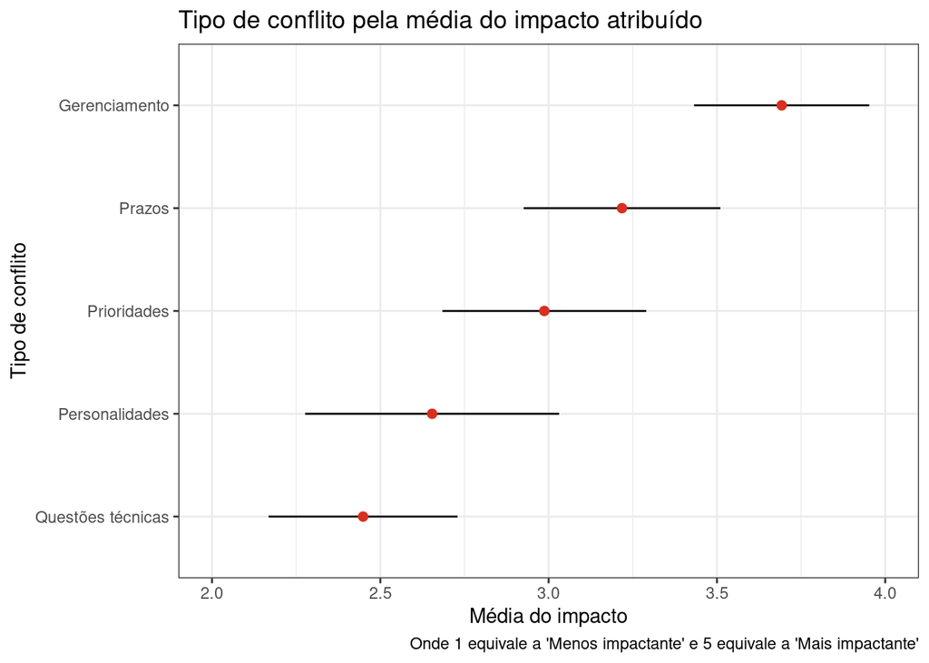

```r
respostas_uteis %>%
  select(starts_with("impacto_")) %>%
  summarise(across(.fns = c("mean" = mean, "var" = var), .names = "{.col}_{.fn}")) %>%
  pivot_longer(
    cols = starts_with("impacto_"),
    names_to = "tipo_de_conflito",
    values_to = "value"
  ) %>% rowwise() %>%
  mutate(
    metric = str_split(tipo_de_conflito, "_")[[1]][3],
    tipo_de_conflito = str_split(tipo_de_conflito, "_")[[1]][2],
    tipo_de_conflito = case_when(
      tipo_de_conflito == "prioridades" ~ "Prioridades",
      tipo_de_conflito == "gerenciamento" ~ "Gerenciamento",
      tipo_de_conflito == "tecnico" ~ "Questões técnicas",
      tipo_de_conflito == "prazos" ~ "Prazos",
      tipo_de_conflito == "personalidade" ~ "Personalidades",
    )
  ) %>% ungroup() %>%
  pivot_wider(id_cols = tipo_de_conflito, values_from = "value", names_from = "metric") %>%
  mutate(ic.low = mean + qt(0.025, df = size_d-1) * sqrt(var/size_d),
         ic.high = mean + qt(0.975, df = size_d-1) * sqrt(var/size_d)) %>%
  ggplot(aes(y = reorder(tipo_de_conflito, mean))) +
  geom_linerange(aes(xmin = ic.low, xmax = ic.high)) +
  geom_point(aes(x = mean), color = '#d7301f', size = 2) +
  scale_x_continuous(limits = c(2, 4)) +
  labs(title = "Tipo de conflito pela média do impacto atribuído",
       y = "Tipo de conflito",
       x = "Média do impacto",
       caption = "Onde 1 equivale a 'Menos impactante' e 5 equivale a 'Mais impactante'")
```

### QP3: Quais as principais soluções aplicadas pelo time para o gerenciamento de conflitos?

Pelos gráficos, é possível notar dois grupos que se diferenciam pela frequência.

O primeiro formado por **Confronto**, **Negociação** e **Apaziguamento** traz técnicas que são mais colaborativas e que apresentam altas frequências de aplicação, com médias próximas, superiores a 3, e sobreposição em seus intervalos de confiança.

Entretanto, temos um segundo grupo formado pelas técnicas que são aplicadas menos frequentemente e possuem um maior caratér individual: **Evasão** e **Imposição**. Novamente suas médias são próximas e há sobreposição de seus intervalos.

#### Gráfico V

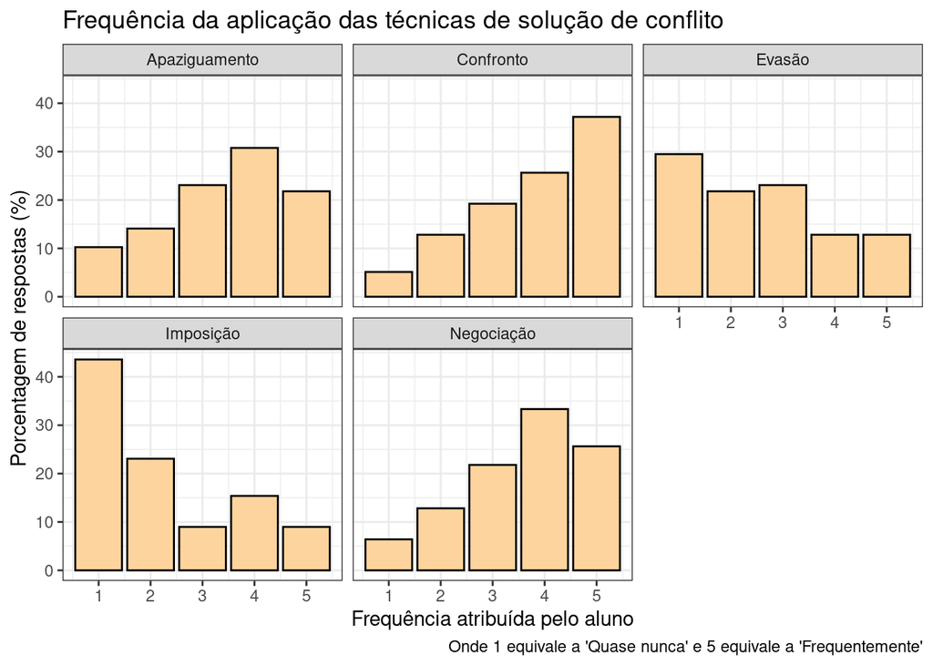

```r
respostas_uteis %>%
  select(starts_with("solucao_")) %>%
  pivot_longer(
    cols = starts_with("solucao_"),
    names_to = "tipo_de_solucao",
    values_to = "freq"
  ) %>%
  mutate(
    tipo_de_solucao = case_when(
      tipo_de_solucao == "solucao_confronto" ~ "Confronto",
      tipo_de_solucao == "solucao_negociacao" ~ "Negociação",
      tipo_de_solucao == "solucao_evasao" ~ "Evasão",
      tipo_de_solucao == "solucao_apazig" ~ "Apaziguamento",
      tipo_de_solucao == "solucao_imposicao" ~ "Imposição",
    )
  ) %>%
  count(tipo_de_solucao, freq) %>%
  mutate(n = n/size_d * 100) %>%
  ggplot(aes(x = freq, y = n)) +
  geom_bar(stat = 'identity', position = 'dodge', color = 'black', fill = '#fdd49e') +
  facet_wrap( ~ tipo_de_solucao) +
  labs(x = "Frequência atribuída pelo aluno",
       y = "Porcentagem de respostas (%)",
       caption = "Onde 1 equivale a 'Quase nunca' e 5 equivale a 'Frequentemente'",
       title = "Frequência da aplicação das técnicas de solução de conflito")
```

#### Gráfico VI

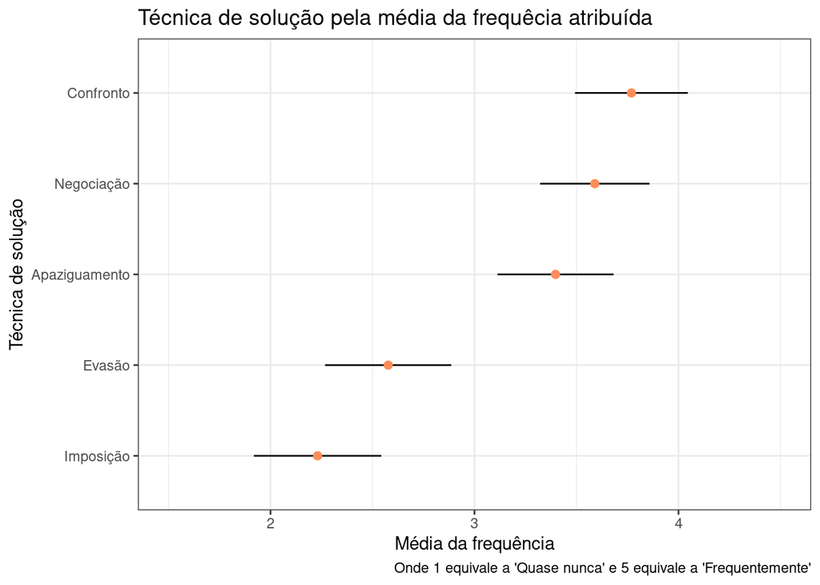

```r
respostas_uteis %>%
  select(starts_with("solucao_")) %>%
  summarise(across(.fns = c("mean" = mean, "var" = var), .names = "{.col}_{.fn}")) %>%
  pivot_longer(
    cols = starts_with("solucao_"),
    names_to = "tipo_de_solucao",
    values_to = "value"
  ) %>% rowwise() %>%
  mutate(
    metric = str_split(tipo_de_solucao, "_")[[1]][3],
    tipo_de_solucao = str_split(tipo_de_solucao, "_")[[1]][2],
    tipo_de_solucao = case_when(
      tipo_de_solucao == "confronto" ~ "Confronto",
      tipo_de_solucao == "negociacao" ~ "Negociação",
      tipo_de_solucao == "evasao" ~ "Evasão",
      tipo_de_solucao == "apazig" ~ "Apaziguamento",
      tipo_de_solucao == "imposicao" ~ "Imposição",
    )
  ) %>% ungroup() %>%
  pivot_wider(id_cols = tipo_de_solucao, values_from = "value", names_from = "metric") %>%
  mutate(ic.low = mean + qt(0.025, df = size_d-1) * sqrt(var/size_d),
         ic.high = mean + qt(0.975, df = size_d-1) * sqrt(var/size_d)) %>%
  ggplot(aes(y = reorder(tipo_de_solucao, mean))) +
  geom_linerange(aes(xmin = ic.low, xmax = ic.high)) +
  geom_point(aes(x = mean), color = '#fc8d59', size = 2) +
  scale_x_continuous(limits = c(1.5, 4.5)) +
  labs(title = "Técnica de solução pela média da frequêcia atribuída",
       y = "Técnica de solução",
       x = "Média da frequência",
       caption = "Onde 1 equivale a 'Quase nunca' e 5 equivale a 'Frequentemente'")
```

### QP4: Quais das soluções de gestão tiveram maior impacto positivo no desenvolvimento do projeto?

#### Gráfico VII

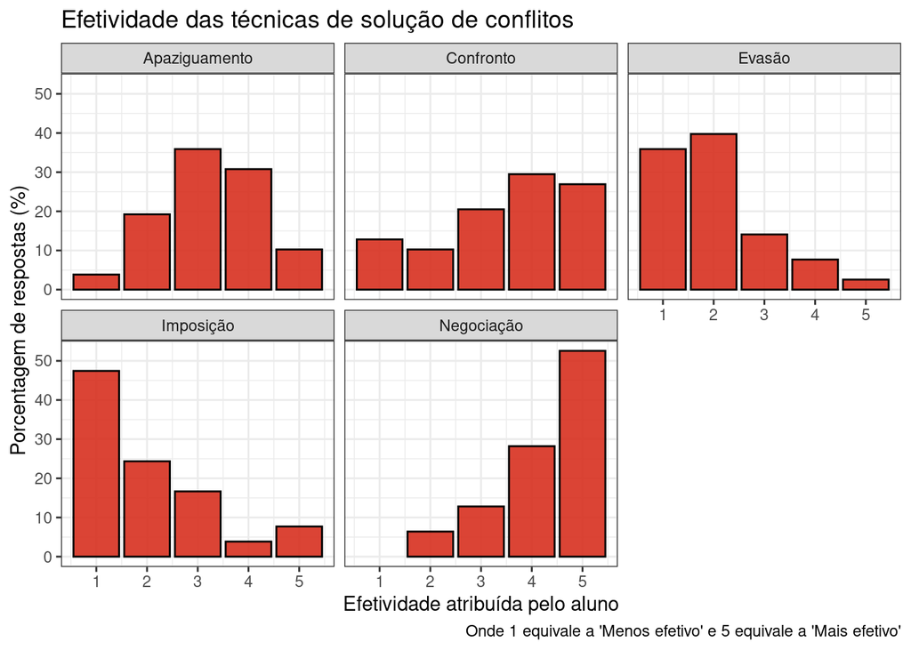

```r
respostas_uteis %>%
  select(starts_with("efetividade_")) %>%
  pivot_longer(
    cols = starts_with("efetividade_"),
    names_to = "tipo_de_solucao",
    values_to = "efetividade"
  ) %>%
  mutate(
    tipo_de_solucao = case_when(
      tipo_de_solucao == "efetividade_confronto" ~ "Confronto",
      tipo_de_solucao == "efetividade_negociacao" ~ "Negociação",
      tipo_de_solucao == "efetividade_evasao" ~ "Evasão",
      tipo_de_solucao == "efetividade_apazig" ~ "Apaziguamento",
      tipo_de_solucao == "efetividade_imposicao" ~ "Imposição",
    )
  ) %>%
  count(tipo_de_solucao, efetividade) %>%
  mutate(n = n/size_d * 100) %>%
  ggplot(aes(x = efetividade, y = n)) +
  geom_bar(stat = 'identity', position = 'dodge', color = 'black', fill = '#d7301f', alpha = .9) +
  facet_wrap( ~ tipo_de_solucao) +
  labs(x = "Efetividade atribuída pelo aluno",
       y = "Porcentagem de respostas (%)",
       caption = "Onde 1 equivale a 'Menos efetivo' e 5 equivale a 'Mais efetivo'",
       title = "Efetividade das técnicas de solução de conflitos")
```

#### Gráfico VIII

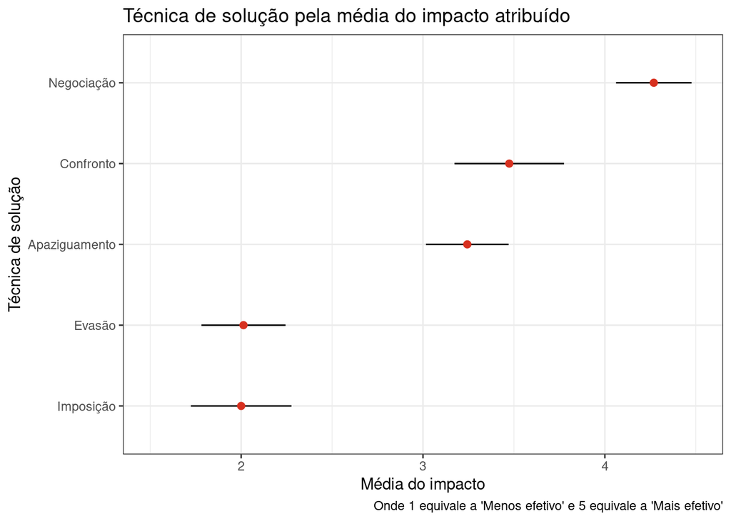

```r
respostas_uteis %>%
  select(starts_with("efetividade_")) %>%
  summarise(across(.fns = c("mean" = mean, "var" = var), .names = "{.col}_{.fn}")) %>%
  pivot_longer(
    cols = starts_with("efetividade_"),
    names_to = "tipo_de_solucao",
    values_to = "value"
  ) %>% rowwise() %>%
  mutate(
    metric = str_split(tipo_de_solucao, "_")[[1]][3],
    tipo_de_solucao = str_split(tipo_de_solucao, "_")[[1]][2],
    tipo_de_solucao = case_when(
      tipo_de_solucao == "confronto" ~ "Confronto",
      tipo_de_solucao == "negociacao" ~ "Negociação",
      tipo_de_solucao == "evasao" ~ "Evasão",
      tipo_de_solucao == "apazig" ~ "Apaziguamento",
      tipo_de_solucao == "imposicao" ~ "Imposição",
    )
  ) %>% ungroup() %>%
  pivot_wider(id_cols = tipo_de_solucao, values_from = "value", names_from = "metric") %>%
  mutate(ic.low = mean + qt(0.025, df = size_d-1) * sqrt(var/size_d),
         ic.high = mean + qt(0.975, df = size_d-1) * sqrt(var/size_d)) %>%
  ggplot(aes(y = reorder(tipo_de_solucao, mean))) +
  geom_linerange(aes(xmin = ic.low, xmax = ic.high)) +
  geom_point(aes(x = mean), color = '#d7301f', size = 2) +
  scale_x_continuous(limits = c(1.5, 4.5)) +
  labs(title = "Técnica de solução pela média do impacto atribuído",
       y = "Técnica de solução",
       x = "Média do impacto",
       caption = "Onde 1 equivale a 'Menos efetivo' e 5 equivale a 'Mais efetivo'")
```